# Simple Peripheral

- Introduction
- Hardware Prerequisites
- Software Prerequisites
- Service/Profile Table
- Usage
  - Characteristic 1 (UUID: FFF1)
  - Characteristic 2 (UUID: FFF2)
  - Characteristic 3 (UUID: FFF3)
  - Characteristic 4 (UUID: FFF4)
  - Characteristic 5 (UUID: FFF5)

## Introduction

The `simple_peripheral` project implements a simple Bluetooth low energy peripheral device with GATT services and demonstrates the TI Simple Profile. This project can be a framework for developing many different peripheral-role applications. The Simple Peripheral project is used as the baseline for explaining the stack in the **BLE5-Stack User’s Guide**.

This project has the following app configurations available:

[output not shown]

All application configurations use the stack library configuration, FlashROM_Library. This build configuration will yield additional flash footprint optimizations by the linker since the application and stack can share contiguous flash pages. This configuration is further discussed in the Stack Library Configuration section of the **BLE5-Stack User’s Guide** provided in the SDK.

## Hardware Prerequisites

The default Simple Peripheral board configuration uses the device’s LaunchPad development kit. This hardware configuration is shown in the below image:

[figure not shown]

For custom hardware, see the Running the SDK on Custom Boards section of the **BLE5-Stack User’s Guide**.

## Software Prerequisites

For information on what versions of Code Composer Studio and IAR Embedded Workbench to use, see the Release Notes file provided in the SDK. For information on how to import this project into your IDE workspace and build/run, please refer to the device’s Platform section in the **BLE5-Stack User’s Guide**.

## Service/Profile Table

This project contains 1 service, which has 5 characteristics.

Note that BLE Scanner may report 128 bit UUIDs, but the project is generating 16 bit UUIDs.

| Characterisitic | UUID | Format | Properties | Profile Source |
| --- | --- | --- | --- | --- |
| 1 | FFF1 | 1 Byte Integer | Read/Write | simple_peripheral.c/simple_gatt_profile.c |
| 2 | FFF2 | 1 Byte Integer | Read | simple_peripheral.c/simple_gatt_profile.c |
| 3 | FFF3 | 1 Byte Integer | Write | simple_peripheral.c/simple_gatt_profile.c |
| 4 | FFF4 | 1 Byte Integer | Notify | simple_peripheral.c/simple_gatt_profile.c |
| 5 | FFF5 | 5 Byte Integer | Read | simple_peripheral.c/simple_gatt_profile.c |

## Usage

This application uses the UART peripheral to provide an interface for the application. The UART is only used for display messages.

This document will use a terminal program (Tera Term, PuTTY, etc.) to serve as the display for the output of the LaunchPad, and it will use a BLE phone app, such as BLE Scanner (Android) or LightBlue Explorer (iOS), that will act as the central device that will connect to the Simple Peripheral device. This document will be using Tera Term and BLE Scanner. Note that any other serial terminal and smartphone BLE application can be used. The following default parameters are used for the UART peripheral for display:

| UART Param | Default Values |
| --- | --- |
| Baud Rate | 115200 |
| Data length | 8 bits |
| Parity | None |
| Stop bits | 1 bit |
| Flow Control | None |

Once the Simple Peripheral sample application starts, the output to the terminal will report it’s address and the fact that it is advertising, as shown below:

[figure not shown]

Advertising is enabled by default upon startup, so there is no need to physically press a button to start advertising. Using BLE Scanner to scan for the device, you should see a device with the name of SimplePeripheral (note that the navigation might be slightly different depending on your mobile application):

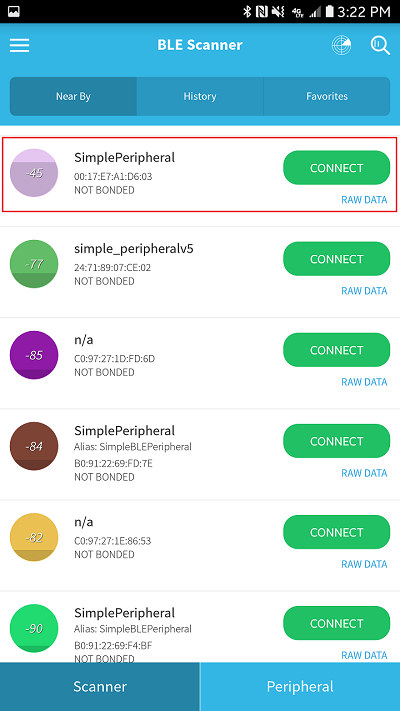

If there is more than 1 device called SimplePeripheral, the RSSI value in the colored circles on the left can be used to find which device you are trying to connect to. Press the “connect” button to connect to the device. Once connected, the terminal window will show the address of the connected device (smartphone):

[figure not shown]

After a connection is formed, you will also have the option to switch which physical layer (PHY) preference is used. Use the left button (BTN-1) to move to the next option and the right button (BTN-2) to select an option. For more information on the differences between the PHY options, see the PHY section of the **BLE5-Stack User’s Guide**.

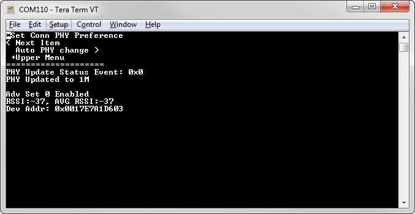

In BLE Scanner, you should be able to see various information about the Simple Peripheral device:

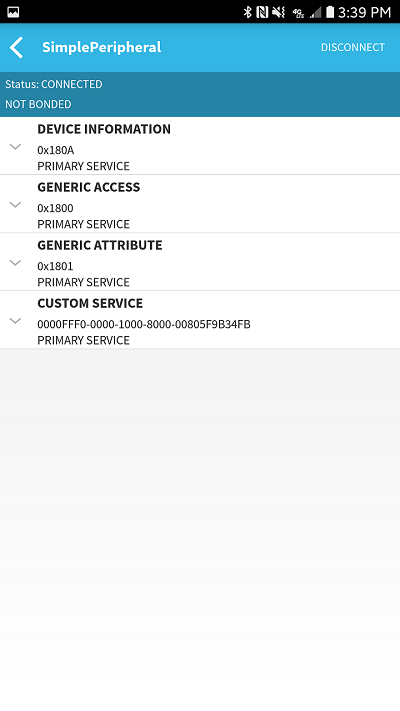

You should see 1 service, which is labeled as “CUSTOM SERVICE” (this may be slightly different for other smartphone applications). It will also provide its UUID. Clicking on this service will display the 5 characteristics that it contains, with information about each characteristic:

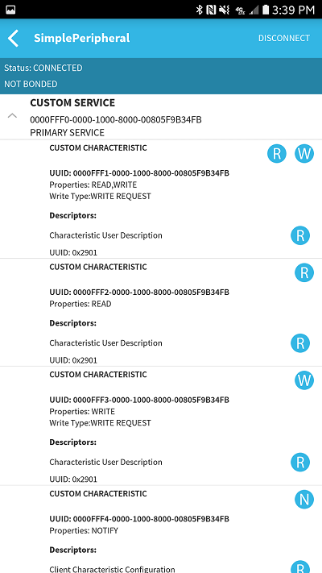

Scrolling down should show all 5 characteristics. The following sections detail the functions and operations of each of the characteristics.

### Characteristic 1 (UUID: FFF1)

This characteristic demonstrates both read and write properties, and it contains a 1-byte-long value. As shown below, there are 2 circles, one with an “R” and one with a “W”, next to “CUSTOM CHARACTERISTIC”:

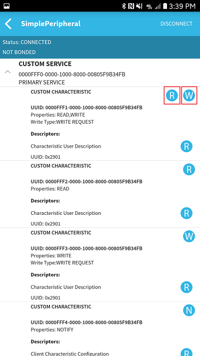

These are the buttons used for read and write operations. The value for this characteristic is set to “01” by default, and it can be changed by pressing the write button. Upon pressing the write button, you will see the following menu:

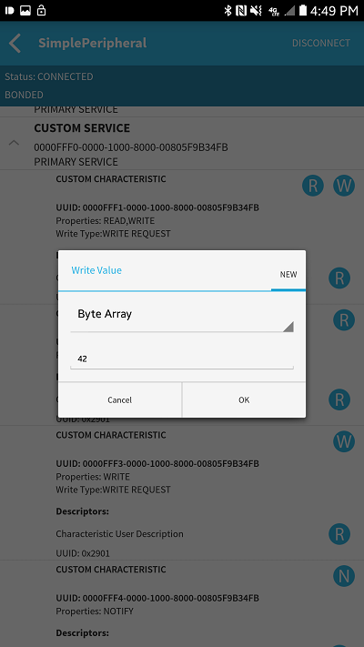

To write a new byte value to it, click on “Text” to change it to “Byte Array”, and then enter the value that you want to write to the characteristic (in hexadecimal) in the field below. Press ok, and then you will be able to see that the value has changed by looking at the terminal window. The example below shows a write of `0x42` which is decimal for 66:

[figure not shown]

Note that the terminal window will print the value in decimal. The value will also be updated in BLE Scanner:

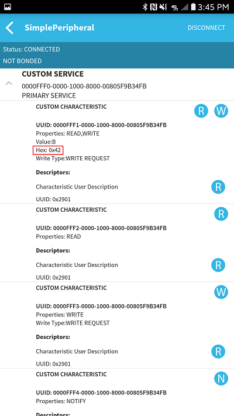

The read button can be used to read a value. If the Simple Peripheral device has changed the value of the characteristic (i.e. by using a button press), then pressing the read button will show the updated value in BLE scanner as shown above.

There is also a circle with an “R” next to “Characteristic User Description”. Pressing this will show the name of the characteristic, as shown below:

[figure not shown]

### Characteristic 2 (UUID: FFF2)

This characteristic has read property only. Its value can be read following the same procedure as is detailed for characteristic 1. It has a default value of 0x02.

### Characteristic 3 (UUID: FFF3)

This characteristic has write property only. Its value can be written to following the same procedure as is detailed for characteristic 1. It has a default value of 0x03.

### Characteristic 4 (UUID: FFF4)

This characteristic has notify property only. It is a single byte, and it is set to whatever value is contained in characteristic 3 (this value can be changed by writing to characteristic 3). Next to “CUSTOM CHARACTERISTIC” there is a circle with an “N”. Pressing this button will enable notifications, and this characteristic will be updated and will display the value contained in characteristic 3:

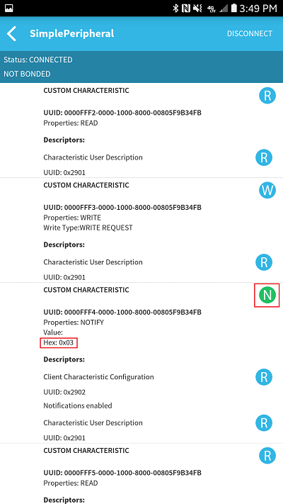

Before pressing the notify button, the read button next to “Client Characteristic Configuration” can be pressed to show whether notifications (or indications) have been enabled:

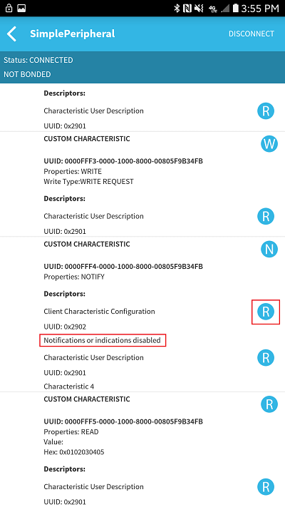

Once notifications have been enabled, this will be displayed:

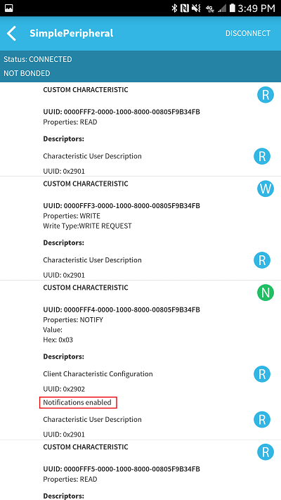

### Characteristic 5 (UUID: FFF5)

This characteristic has read property only. It is 5 bytes, and its default value is 0x0102030405. It differs from the other characteristics in that it requires authentication. This is done by pairing the smartphone with the Simple Peripheral device. The process of doing this varies depending on the smartphone application and the operating system that is being used. Please see documentation on the operating system that you are using for more details. Some documentation for iOS can be found [**here**](https://support.apple.com/en-us/HT204091), and some for Android can be found [**here**](https://support.google.com/nexus/answer/2819579?hl=en). If the Simple Peripheral device and the smartphone have not been paired, you will not see anything when you press the read button (this includes reading the characteristic user description).

When prompted for a passcode on the phone to pair, the passcode will be displayed on the terminal:

[figure not shown]

Once the devices are paired, pressing the read button will show the characteristic’s value as shown below:

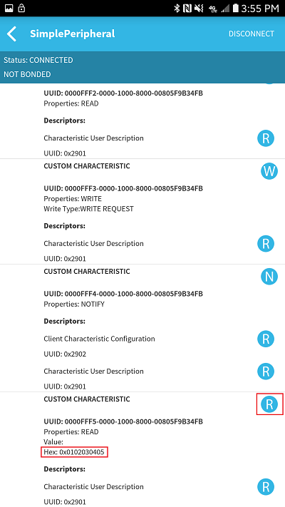